# Visualizing Errors: Error Bars

Youmi Suk

3. 13. 2022

## Bar plots with COVID data

### Bar plots

```r
covids <- read_csv(paste0(path1, "WHO-COVID-19-global-table-data.csv"))
DT::datatable(covids, options = list(scrollX = T))
```

|  | Name | WHO Region | Cases - cumulative total | Cases - cumulative total per 100000 population | Cases - newly reported in last 7 days | Cases - newly reported in last 7 days per 100000 population | Cases - newly reported in last 24 hours | Deaths - cumulative total | Deaths - cumulative total per 100000 population | Deaths - newly reported in last 7 days | Deaths - newly reported in last 7 days per 100000 population | Deaths - newly reported in last 24 hours |
| --- | --- | --- | --- | --- | --- | --- | --- | --- | --- | --- | --- | --- |
| 1 | Global |  | 242688319 | 3113.56805946587 | 2334543 | 29.9510027849738 | 116665 | 4932928 | 63.2869646290839 | 38615 | 0.495410867369659 | 1607 |
| 2 | United States of America | Americas | 44940696 | 13577.141 | 346399 | 104.651 | 0 | 726846 | 219.589 | 8144 | 2.46 | 0 |
| 3 | India | South-East Asia | 34189774 | 2477.512 | 108459 | 7.859 | 14306 | 454712 | 32.95 | 2422 | 0.176 | 443 |
| 4 | Brazil | Americas | 21680488 | 10199.731 | 53012 | 24.94 | 0 | 604228 | 284.263 | 1559 | 0.733 | 0 |
| 5 | The United Kingdom | Europe | 8641225 | 12729.023 | 236752 | 348.749 | 0 | 139146 | 204.97 | 619 | 0.912 | 0 |
| 6 | Russian Federation | Europe | 8168305 | 5597.242 | 175618 | 120.34 | 0 | 228453 | 156.545 | 5141 | 3.523 | 0 |
| 7 | Turkey | Europe | 7772604 | 9215.9 | 142441 | 168.891 | 0 | 68472 | 81.187 | 1035 | 1.227 | 0 |
| 8 | France | Europe | 6899508 | 10608.204 | 34175 | 52.545 | 6291 | 115088 | 176.951 | 186 | 0.286 | 23 |
| 9 | Iran (Islamic Republic of) | Eastern Mediterranean | 5851670 | 6966.859 | 78251 | 93.164 | 7081 | 125052 | 148.884 | 1176 | 1.4 | 124 |
| 10 | Argentina | Americas | 5275984 | 11673.622 | 4623 | 10.229 | 0 | 115770 | 256.152 | 110 | 0.243 | 0 |

[output cut: 228 more lines]

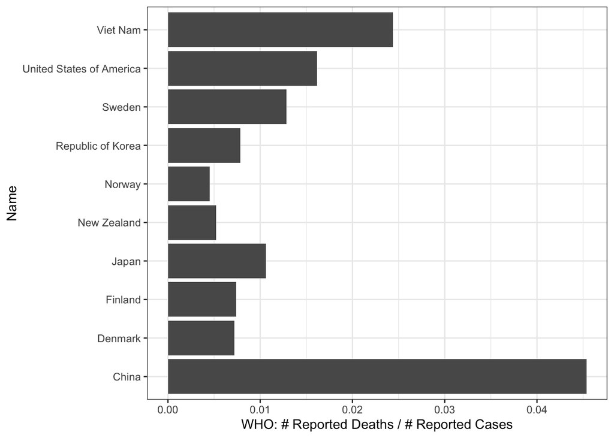

```r
focus <- c('Sweden', 'United States of America', 'Denmark', 'Finland', 'Norway',
           'Republic of Korea', 'Japan', 'China', 'Viet Nam', 'New Zealand')

covids %>% filter(Name %in% focus) %>% mutate(rate = `Deaths - cumulative total`/`Cases - cumulative total`) %>%
ggplot(aes(x=rate, y=Name)) + geom_col() + theme_bw() + xlab('WHO: # Reported Deaths / # Reported Cases')
```

### Error bars

- Theoretical uncertainty in an estimate of a proportion
1. $\textrm{First we use} \; Variance \; \textrm{of a coin flip with probability p:}\; p(1-p)$
2. $\textrm{Then we calculate the} \; Variance \; \textrm{of an average of coin flips:}\; p(1-p)/n$
3. $\textrm{Then we calculate the} \; Standard \; Deviation \; \textrm{of an average of coin flips:}\; \sqrt{p(1-p)/n}$
4. $\textrm{And when you estimate this with the observed sample proprotion it's called the} \; Standard \; Error:\; \sqrt{\hat p(1-\hat p)/n}$

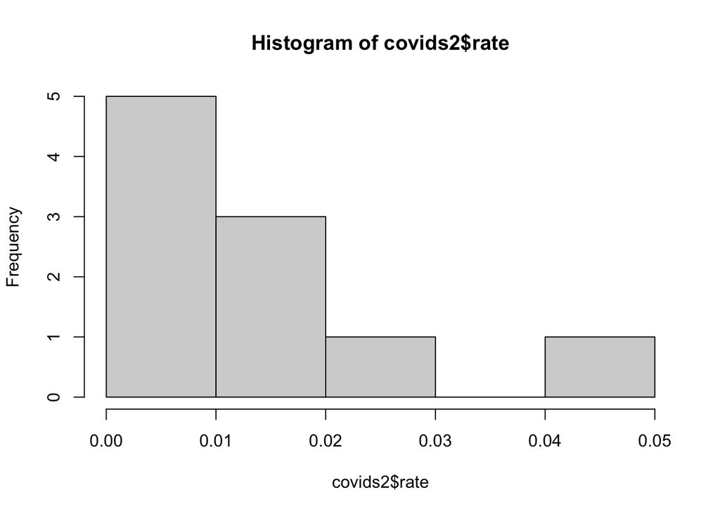

```r
covids2 <- covids %>% filter(Name %in% focus) %>%
  mutate(rate = `Deaths - cumulative total`/`Cases - cumulative total`,
         SE = sqrt(rate*(1-rate)/`Cases - cumulative total`))

hist(covids2$rate) # histogram of death rates
```

- Add error bars.

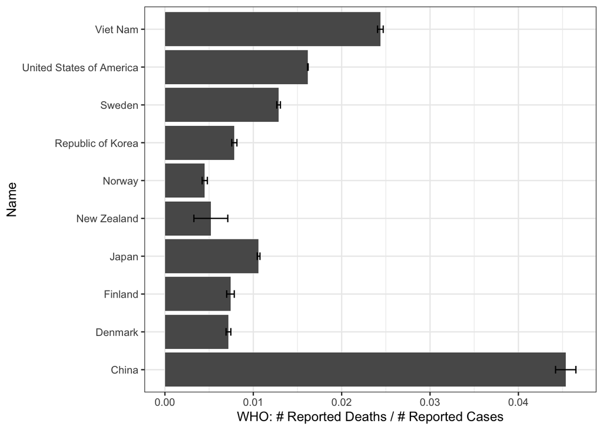

```r
ggplot(covids2, aes(x=rate, y=Name)) + geom_col() + theme_bw() +
  xlab('WHO: # Reported Deaths / # Reported Cases') +
  geom_errorbar(aes(xmin=rate-1.96*SE, xmax=rate+1.96*SE), width=.2)
```

- What is driving the degree of uncertainty?
  - Do we trust these estimates?
  - How could death rates should vary by country?

## Bar plots with incex data

- Load data

```r
# load incex data
incex <- read.table(paste0(path2, 'income_exmpl.dat'), header = T, sep = "\t")

# change order of factor levels
incex$occ <- factor(incex$occ, levels = c('low', 'med.', 'high'))
incex$edu <- factor(incex$edu, levels = c('low', 'med.', 'high'))
incex$sex <- factor(incex$sex, levels = c('m', 'f'), labels = c('male', 'female'))
```

- First, summarize the data. This can be done in many ways, as described on [R cookbook](http://www.cookbook-r.com/Manipulating_data/Summarizing_data/). In class, we’ll use the `summarySE()` function below.

```r
## Summarizes data.
## Gives count, mean, standard deviation, standard error of the mean, and confidence interval (default 95%).
##   data: a data frame.
##   measurevar: the name of a column that contains the variable to be summariezed
##   groupvars: a vector containing names of columns that contain grouping variables
##   na.rm: a boolean that indicates whether to ignore NA's
##   conf.interval: the percent range of the confidence interval (default is 95%)
summarySE <- function(data=NULL, measurevar, groupvars=NULL, na.rm=FALSE,
                      conf.interval=.95, .drop=TRUE) {
    library(plyr)

    # New version of length which can handle NA's: if na.rm==T, don't count them
    length2 <- function (x, na.rm=FALSE) {
        if (na.rm) sum(!is.na(x))
        else       length(x)
    }

    # This does the summary. For each group's data frame, return a vector with
    # N, mean, and sd
    datac <- ddply(data, groupvars, .drop=.drop,
      .fun = function(xx, col) {
        c(N    = length2(xx[[col]], na.rm=na.rm),
          mean = mean   (xx[[col]], na.rm=na.rm),
          sd   = sd     (xx[[col]], na.rm=na.rm)
        )
      },
      measurevar
    )

    # Rename the "mean" column
    datac <- rename(datac, c("mean" = measurevar))

    datac$se <- datac$sd / sqrt(datac$N)  # Calculate standard error of the mean

    # Confidence interval multiplier for standard error
    # Calculate t-statistic for confidence interval:
    # e.g., if conf.interval is .95, use .975 (above/below), and use df=N-1
    ciMult <- qt(conf.interval/2 + .5, datac$N-1)
    datac$ci <- datac$se * ciMult

    return(datac)
}
```

- Get standard errors and marginal errors.
  - Margin of error: distance between the point estimate and the lower or upper confidence limit.

```r
incex_grp <- summarySE(incex, measurevar="income", groupvars=c("occ","sex"))
str(incex_grp)
```

```
## 'data.frame':    6 obs. of  7 variables:
##  $ occ   : Factor w/ 3 levels "low","med.","high": 1 1 2 2 3 3
##  $ sex   : Factor w/ 2 levels "male","female": 1 2 1 2 1 2
##  $ N     : num  223 372 394 306 452 175
##  $ income: num  1148 1023 1353 1204 1607 ...
##  $ sd    : num  142 139 144 136 158 ...
##  $ se    : num  9.49 7.2 7.27 7.78 7.41 ...
##  $ ci    : num  18.7 14.2 14.3 15.3 14.6 ...
```

```r
kable(incex_grp)
```

| occ | sex | N | income | sd | se | ci |
| --- | --- | --- | --- | --- | --- | --- |
| low | male | 223 | 1147.601 | 141.7076 | 9.489445 | 18.70092 |
| low | female | 372 | 1023.059 | 138.8434 | 7.198696 | 14.15536 |
| med. | male | 394 | 1352.975 | 144.2848 | 7.268963 | 14.29092 |
| med. | female | 306 | 1203.853 | 136.1378 | 7.782479 | 15.31415 |
| high | male | 452 | 1606.881 | 157.5898 | 7.412402 | 14.56713 |
| high | female | 175 | 1483.491 | 132.3516 | 10.004842 | 19.74647 |

- Use standard error bars of the mean

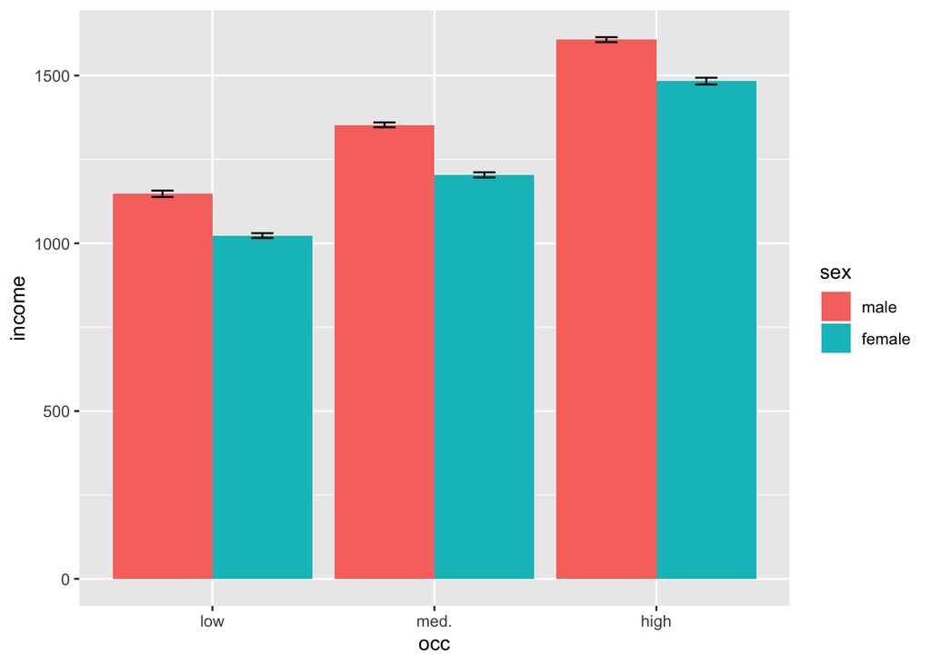

```r
ggplot(incex_grp, aes(x = occ, y=income, fill=sex)) +
    geom_bar(position=position_dodge(), stat="identity") +
    geom_errorbar(aes(ymin=income-se, ymax=income+se),
                  width=.2,                    # Width of the error bars
                  position=position_dodge(.9))
```

- Use marginal errors instead of standard errors to construct 95% confidence intervals.

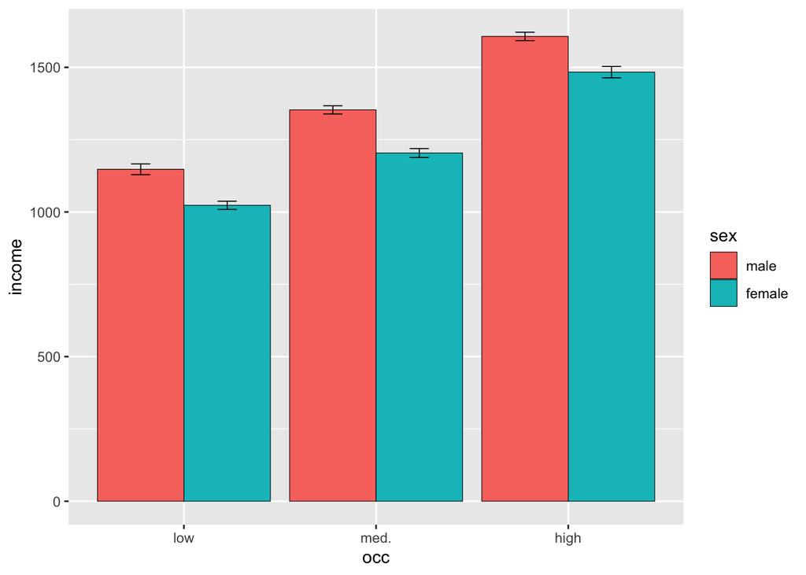

```r
ggplot(incex_grp, aes(x = occ, y=income, fill=sex)) +
    geom_bar(position=position_dodge(), stat="identity", col="black", size=.2) +
    geom_errorbar(aes(ymin=income-ci, ymax=income+ci),
                  width=.2, # Width of the error bars
                  size=.3,
                  position=position_dodge(.9))
```

- The graph can be improved using additional functions (e.g., `labs`, `theme_...`, `scale_...`) as:

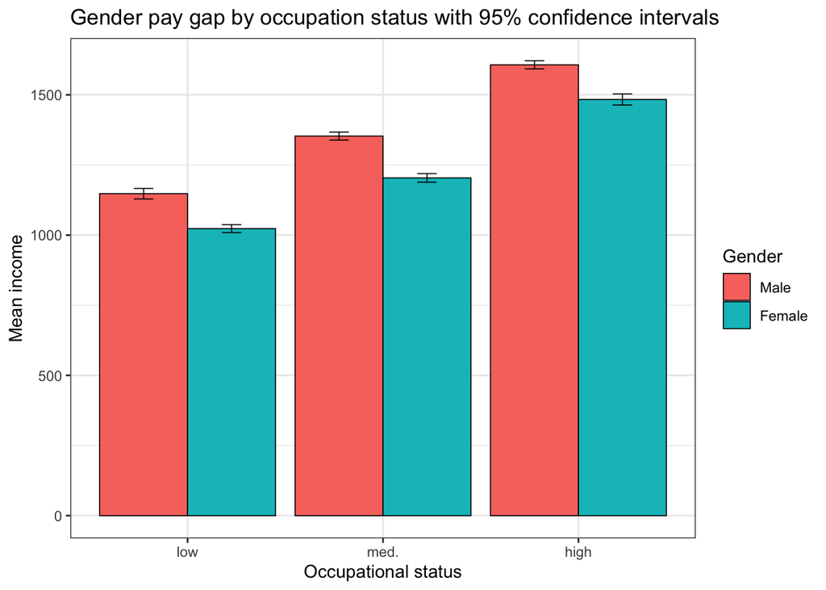

```r
ggplot(incex_grp, aes(x = occ, y=income, fill=sex)) +
    geom_bar(position=position_dodge(), stat="identity",
             colour="black", # Use black outlines,
             size=.3) +      # Thinner lines
    geom_errorbar(aes(ymin=income-ci, ymax=income+ci),
                  size=.3,    # Thinner lines
                  width=.2,                    # Width of the error bars
                  position=position_dodge(.9)) +
    labs(x="Occupational status", y="Mean income", title="Gender pay gap by occupation status with 95% confidence intervals") +
    scale_fill_hue(name="Gender", # Legend label, use darker colors
                   breaks=c("male", "female"),
                   labels=c("Male", "Female")) +
    theme_bw()
```

## Line plots

- We could summarize the above data using a line graph. That is, we could use basic line and point graph with error bars representing either the standard error of the mean, or 95% confidence interval.

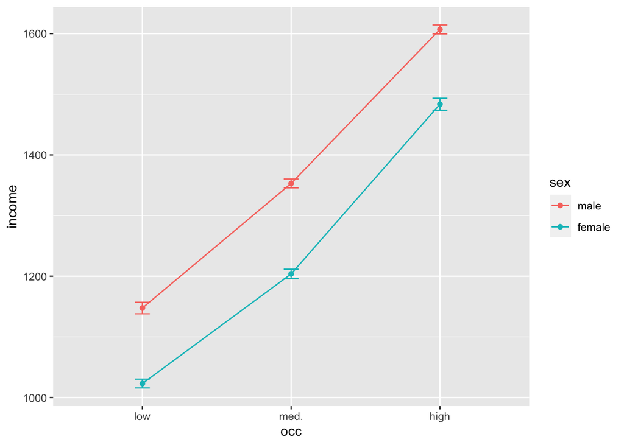

```r
# Standard error of the mean
ggplot(incex_grp, aes(x = occ, y=income, col=sex, group=sex)) +
    geom_line() + geom_point() +
    geom_errorbar(aes(ymin=income-se, ymax=income+se),
                  width=.1)
```

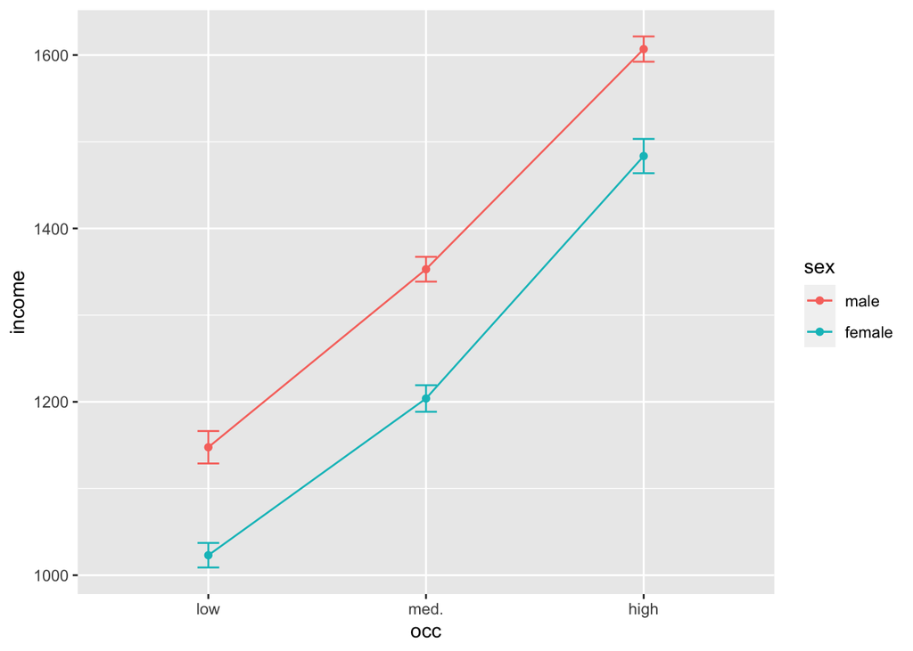

```r
# Standard error of the mean
ggplot(incex_grp, aes(x = occ, y=income, col=sex, group=sex)) +
    geom_line() + geom_point() +
    geom_errorbar(aes(ymin=income-ci, ymax=income+ci),
                  width=.1)
```

- Use a subset of 50 cases.

```r
set.seed(1)
incex2 <- sample_n(incex, 50, replace=FALSE) # randomly sample 50 cases.

incex_grp2 <- summarySE(incex2, measurevar="income", groupvars=c("occ","sex"))
str(incex_grp2)
```

```
## 'data.frame':    6 obs. of  7 variables:
##  $ occ   : Factor w/ 3 levels "low","med.","high": 1 1 2 2 3 3
##  $ sex   : Factor w/ 2 levels "male","female": 1 2 1 2 1 2
##  $ N     : num  7 7 12 7 11 6
##  $ income: num  1152 1044 1286 1192 1653 ...
##  $ sd    : num  112 150 145 156 105 ...
##  $ se    : num  42.4 56.6 41.9 58.9 31.6 ...
##  $ ci    : num  103.8 138.6 92.1 144.1 70.4 ...
```

```r
kable(incex_grp2)
```

| occ | sex | N | income | sd | se | ci |
| --- | --- | --- | --- | --- | --- | --- |
| low | male | 7 | 1152.143 | 112.1910 | 42.40419 | 103.75932 |
| low | female | 7 | 1044.143 | 149.8771 | 56.64822 | 138.61319 |
| med. | male | 12 | 1286.250 | 145.0223 | 41.86434 | 92.14279 |
| med. | female | 7 | 1192.143 | 155.7931 | 58.88424 | 144.08455 |
| high | male | 11 | 1652.909 | 104.7907 | 31.59558 | 70.39935 |
| high | female | 6 | 1459.500 | 138.7181 | 56.63141 | 145.57568 |

- Draw error bars.

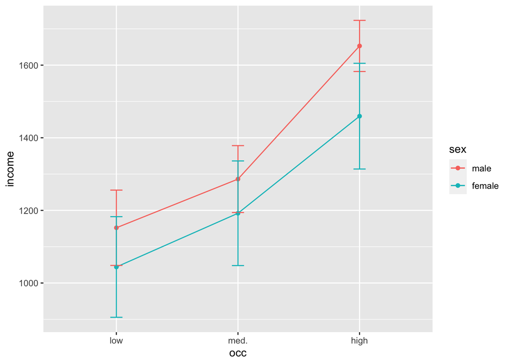

```r
ggplot(incex_grp2, aes(x = occ, y=income, col=sex, group=sex)) +
    geom_line() + geom_point() +
    geom_errorbar(aes(ymin=income-ci, ymax=income+ci),
                  width=.1)
```

- To avoid overlapped errorbars, use `position_dodge` to move them horizontally.

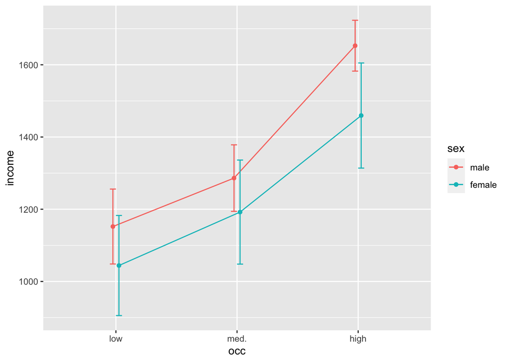

```r
ggplot(incex_grp2, aes(x = occ, y=income, col=sex, group=sex)) +
    geom_line(position=position_dodge(0.1)) +
    geom_point(position=position_dodge(0.1)) +
    geom_errorbar(aes(ymin=income-ci, ymax=income+ci),
                  width=.1,
                  position=position_dodge(0.1))
```

- Change the size of data points and change the color of error bars.

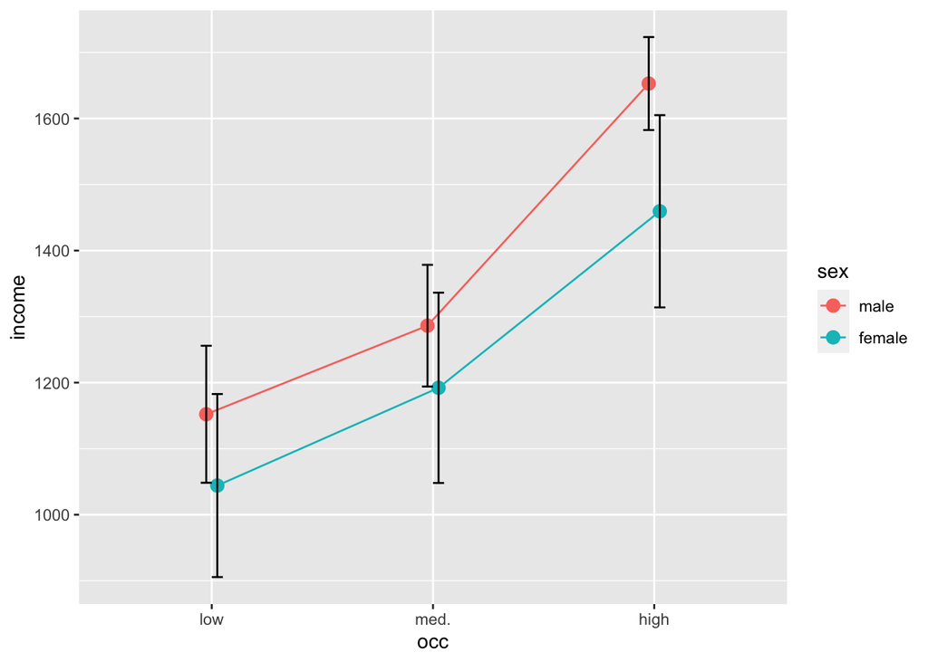

```r
ggplot(incex_grp2, aes(x = occ, y=income, col=sex, group=sex)) +
    geom_line(position=position_dodge(0.1)) +
    geom_point(position=position_dodge(0.1), size=3) +
    geom_errorbar(aes(ymin=income-ci, ymax=income+ci),
                  colour="black",
                  width=.1,
                  position=position_dodge(0.1))
```